# Introduction

The purpose of this notebook is to predict whether the S&P500's closing value will be higher tomorrow than it was today. Utilizing the Yahoo Finance api to soutce the market data and the New York Times api to source news article headlines, sentiment analysis is utilized to enhance the performance of the model. Precision is used as the measure of performance as one would want to minimize the number of false positives, as false positives will lead to a loss of capital. This project follows and is largely inspired by https://youtu.be/1O_BenficgE?si=0evfzADcW9oDJsWQ.

# Loading the Data

Firstly, the data is loaded through the Yahoo Finance api.

```python
import yfinance as yf #calls yahoo finance api to download daily stock and index prices
```

```python
sp500 = yf.Ticker('^GSPC') #initialise ticker class to download price history for a single ticker symbol
# GSPC is the ticker symbol for the S&P 500 index
```

```python
sp500 = sp500.history(period='max') #queries all data of index
```

```python
sp500
```

| Date | Open | High | Low | Close | Volume | Dividends | Stock Splits |
| --- | --- | --- | --- | --- | --- | --- | --- |
| 1927-12-30 00:00:00-05:00 | 17.660000 | 17.660000 | 17.660000 | 17.660000 | 0 | 0.0 | 0.0 |
| 1928-01-03 00:00:00-05:00 | 17.760000 | 17.760000 | 17.760000 | 17.760000 | 0 | 0.0 | 0.0 |
| 1928-01-04 00:00:00-05:00 | 17.719999 | 17.719999 | 17.719999 | 17.719999 | 0 | 0.0 | 0.0 |
| 1928-01-05 00:00:00-05:00 | 17.549999 | 17.549999 | 17.549999 | 17.549999 | 0 | 0.0 | 0.0 |
| 1928-01-06 00:00:00-05:00 | 17.660000 | 17.660000 | 17.660000 | 17.660000 | 0 | 0.0 | 0.0 |
| ... | ... | ... | ... | ... | ... | ... | ... |
| 2024-08-12 00:00:00-04:00 | 5351.879883 | 5371.200195 | 5324.370117 | 5344.390137 | 3360160000 | 0.0 | 0.0 |
| 2024-08-13 00:00:00-04:00 | 5376.979980 | 5436.500000 | 5376.979980 | 5434.430176 | 3648980000 | 0.0 | 0.0 |
| 2024-08-14 00:00:00-04:00 | 5442.359863 | 5463.220215 | 5415.910156 | 5455.209961 | 3380050000 | 0.0 | 0.0 |
| 2024-08-15 00:00:00-04:00 | 5501.129883 | 5546.229980 | 5501.129883 | 5543.220215 | 3723310000 | 0.0 | 0.0 |
| 2024-08-16 00:00:00-04:00 | 5530.500000 | 5561.979980 | 5525.169922 | 5554.250000 | 3357690000 | 0.0 | 0.0 |

24273 rows × 7 columns

```python
sp500.index
```

```
DatetimeIndex(['1927-12-30 00:00:00-05:00', '1928-01-03 00:00:00-05:00',
               '1928-01-04 00:00:00-05:00', '1928-01-05 00:00:00-05:00',
               '1928-01-06 00:00:00-05:00', '1928-01-09 00:00:00-05:00',
               '1928-01-10 00:00:00-05:00', '1928-01-11 00:00:00-05:00',
               '1928-01-12 00:00:00-05:00', '1928-01-13 00:00:00-05:00',
               ...
               '2024-08-05 00:00:00-04:00', '2024-08-06 00:00:00-04:00',
               '2024-08-07 00:00:00-04:00', '2024-08-08 00:00:00-04:00',
               '2024-08-09 00:00:00-04:00', '2024-08-12 00:00:00-04:00',
               '2024-08-13 00:00:00-04:00', '2024-08-14 00:00:00-04:00',
               '2024-08-15 00:00:00-04:00', '2024-08-16 00:00:00-04:00'],
              dtype='datetime64[ns, America/New_York]', name='Date', length=24273, freq=None)
```

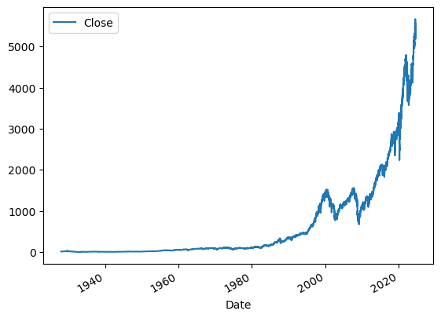

```python
sp500.plot.line(y="Close", use_index=True) #plot the closing price of the S&P 500 index
```

The dividends and stock splits column as they are not of much use in this context. They would be more suitable in the context of individual stocks.

```python
del sp500['Dividends'] #delete dividends column
del sp500['Stock Splits'] #delete stock splits column
```

The target variable is then created.

```python
# setting up our target variable
sp500['Tomorrow'] = sp500["Close"].shift(-1)
```

```python
sp500["Target"] = (sp500["Tomorrow"] > sp500["Close"]).astype(int)
```

The data is then shortened to only include data from the 1990. While it is usually not recommended to delete observations, over time, market fundementals may change and hence, historical data may be of detrement here. Furthermore, it will reduce computational complexity.

```python
sp500 = sp500.loc["1990-01-01 00:00:00-04:00":].copy() #filter data to start from 1990
```

```python
sp500
```

| Date | Open | High | Low | Close | Volume | Tomorrow | Target |
| --- | --- | --- | --- | --- | --- | --- | --- |
| 1990-01-02 00:00:00-05:00 | 353.399994 | 359.690002 | 351.980011 | 359.690002 | 162070000 | 358.760010 | 0 |
| 1990-01-03 00:00:00-05:00 | 359.690002 | 360.589996 | 357.890015 | 358.760010 | 192330000 | 355.670013 | 0 |
| 1990-01-04 00:00:00-05:00 | 358.760010 | 358.760010 | 352.890015 | 355.670013 | 177000000 | 352.200012 | 0 |
| 1990-01-05 00:00:00-05:00 | 355.670013 | 355.670013 | 351.350006 | 352.200012 | 158530000 | 353.790009 | 1 |
| 1990-01-08 00:00:00-05:00 | 352.200012 | 354.239990 | 350.540009 | 353.790009 | 140110000 | 349.619995 | 0 |
| ... | ... | ... | ... | ... | ... | ... | ... |
| 2024-08-12 00:00:00-04:00 | 5351.879883 | 5371.200195 | 5324.370117 | 5344.390137 | 3360160000 | 5434.430176 | 1 |
| 2024-08-13 00:00:00-04:00 | 5376.979980 | 5436.500000 | 5376.979980 | 5434.430176 | 3648980000 | 5455.209961 | 1 |
| 2024-08-14 00:00:00-04:00 | 5442.359863 | 5463.220215 | 5415.910156 | 5455.209961 | 3380050000 | 5543.220215 | 1 |
| 2024-08-15 00:00:00-04:00 | 5501.129883 | 5546.229980 | 5501.129883 | 5543.220215 | 3723310000 | 5554.250000 | 1 |
| 2024-08-16 00:00:00-04:00 | 5530.500000 | 5561.979980 | 5525.169922 | 5554.250000 | 3357690000 | NaN | 0 |

8723 rows × 7 columns

# Initial Model

The model used in this project is a random forest classifier. The purpose of this porject is not to fine tune the classifier but rather to focus on methods that can create a preicse predictor and hence, no hyperparameter tuning is done.

```python
from sklearn.ensemble import RandomForestClassifier

model = RandomForestClassifier(n_estimators = 100, min_samples_split=100, random_state=42)

train = sp500.iloc[:-100]
test = sp500.iloc[-100:]

predictors = ['Close', 'Volume', 'Open', 'High', 'Low']
model.fit(train[predictors], train['Target'])
```

```
RandomForestClassifier(min_samples_split=100, random_state=42)
```

```python
from sklearn.metrics import precision_score

preds = model.predict(test[predictors])
```

```python
import pandas as pd

preds = pd.Series(preds, index = test.index)
```

```python
precision_score(test['Target'], preds)
```

```
0.5
```

A 50% precision score indicates that the model is currently not very precise with half of the positive predictions being false positives. Hence, more work needs to improve this.

# Backtesting System

One way of producing a higher precision score is to create a backtesting system that allows you to train the model on the first x amount fo data then predict the next y days. Then use the first (x+y) days to predict the next y days and so on.

```python
def predict(train, test, predictors, model):
    model.fit(train[predictors], train['Target'])
    preds = model.predict(test[predictors])
    preds = pd.Series(preds, index = test.index, name="Predictions")
    combined = pd.concat([test["Target"], preds], axis=1)
    return combined
```

```python
def backtest(data, model, predictors, start=2500, step=250):
    all_predictions = []

    for i in range(start, data.shape[0], step):
        train = data.iloc[0:i].copy()
        test = data.iloc[i:(i+step)].copy()
        predictions = predict(train, test, predictors, model)
        all_predictions.append(predictions)
    return pd.concat(all_predictions)
```

```python
predictions = backtest(sp500, model, predictors)
```

```python
predictions['Predictions'].value_counts()
```

```
Predictions
0    3508
1    2715
Name: count, dtype: int64
```

An improved precision score, indicating successful backtesting.

```python
precision_score(predictions['Target'], predictions['Predictions'])
```

```
0.5307550644567219
```

```python
predictions["Target"].value_counts()/predictions.shape[0]
```

```
Target
1    0.535594
0    0.464406
Name: count, dtype: float64
```

# Feature Engineering

Furthermore, another way to improve the precision score of the model is to create more features. In this context, it is useful to create rolling averages as markets often follow trends, and identifying those could be quite useful.

```python
# rolling averages
horizons = [2,5,60,250,1000] # ratio between today's closing price and the closing price in these period, a good comparison
new_predictors = []

for h in horizons:
    rolling_average = sp500.rolling(h).mean()

    ratio_column = f"CLose_Ratio_{h}"
    sp500[ratio_column] = sp500["Close"] / rolling_average["Close"]

    trend_column = f"Trend_{h}"
    sp500[trend_column] = sp500.shift(1).rolling(h).sum()["Target"]

    new_predictors += [ratio_column, trend_column]
```

Drop all rows for which the rollign averages cannot be calcuated.

```python
sp500 = sp500.dropna()
```

```python
model = RandomForestClassifier(n_estimators = 200, min_samples_split=10, random_state=42)
```

```python
def predict(train, test, predictors, model):
    model.fit(train[predictors], train['Target'])
    preds = model.predict_proba(test[predictors])[:,1]
    preds[preds >= 0.6] = 1
    preds[preds < 0.6] = 0
    preds = pd.Series(preds, index = test.index, name="Predictions")
    combined = pd.concat([test["Target"], preds], axis=1)
    return combined
```

```python
predictions = backtest(sp500, model, new_predictors) # dont use close etc. absolute and non-informative
```

```python
predictions['Predictions'].value_counts()
```

```
Predictions
0.0    4239
1.0     983
Name: count, dtype: int64
```

Once, again, the precision score increasing with these new predictors.

```python
precision_score(predictions['Target'], predictions['Predictions'])
```

```
0.5717192268565615
```

# Sentiment Analysis

NLP offers us a powerful tool to perform sentiment analysis. By using the NYT api, sentiment analysis can be conducted on the article headlines to help the model predict better. This is a particularly useful application of sentiment analyiss as news articles, and specifically headlines, can play a big role in shaping market confidence. The range of dates are shortened due to the call limits of the API and for the sake of computational simplicity.

```python
# reduce range for efficient article sourcing
sp500 = sp500.loc["2019-01-01 00:00:00-04:00":].copy()
```

```python
from sklearn.ensemble import RandomForestClassifier

model = RandomForestClassifier(n_estimators = 200, min_samples_split=10, random_state=42)

predictors = new_predictors
```

```python
def backtest(data, model, predictors, start=250, step=25):
    all_predictions = []

    for i in range(start, data.shape[0], step):
        train = data.iloc[0:i].copy()
        test = data.iloc[i:(i+step)].copy()
        predictions = predict(train, test, predictors, model)
        all_predictions.append(predictions)
    return pd.concat(all_predictions)
```

```python
# import relevant libraries

import re
import nltk
import bs4
from bs4 import BeautifulSoup
```

```python
from pynytimes import NYTAPI

api_key = "(hidden for privacy)"

nyt = NYTAPI(api_key, parse_dates=True)
```

All articles relevant to the S&P500 are queried form the API.

```python
from datetime import datetime
begin = datetime(2019, 1, 1)
end = datetime(2024, 8, 16)
date_dict = {"begin": begin, "end": end}
options_dict = {"sort":"oldest", 'news_desk': ['Business']}
articles = nyt.article_search(query = 's.&p.', results = 2100, dates = date_dict, options = options_dict)
```

```python
len(articles)
```

```
1541
```

```python
df = pd.DataFrame(articles)
```

```python
df
```

|  | headline | pub_date | byline | type_of_material | _id | uri |
| --- | --- | --- | --- | --- | --- | --- |
| 0 | Volatility Continues as Rising Oil Prices Help... | 2019-01-02 10:04:00+00:00 | {'original': 'By Alexandra Stevenson and Amie ... | News | nyt://article/15d25d5d-7458-52ce-a080-3ae80ddd... | nyt://article/15d25d5d-7458-52ce-a080-3ae80ddd... |
| 1 | DealBook Briefing: What Could Go Wrong in 2019... | 2019-01-02 11:24:11+00:00 | {'original': None, 'person': [], 'organization... | News | nyt://article/f4eb3daa-4354-58f0-b5f6-c2f585bf... | nyt://article/f4eb3daa-4354-58f0-b5f6-c2f585bf... |
| 2 | Chinese Companies Flocked to U.S. Markets in 2... | 2019-01-02 21:54:14+00:00 | {'original': 'By Stephen Grocer', 'person': [{... | News | nyt://article/67449547-31dd-522d-9069-7bd5b221... | nyt://article/67449547-31dd-522d-9069-7bd5b221... |
| 3 | Last Month, Investors Seemed Too Pessimistic. ... | 2019-01-03 09:22:04+00:00 | {'original': 'By Peter Eavis and Binyamin Appe... | News | nyt://article/f3ee0f06-2fad-5753-8bbe-93ff4355... | nyt://article/f3ee0f06-2fad-5753-8bbe-93ff4355... |
| 4 | DealBook Briefing: Apple’s Struggles Add to Un... | 2019-01-03 11:19:35+00:00 | {'original': None, 'person': [], 'organization... | News | nyt://article/6990d0ae-136a-5743-8d5c-095d01d7... | nyt://article/6990d0ae-136a-5743-8d5c-095d01d7... |
| ... | ... | ... | ... | ... | ... | ... |
| 1536 | Starbucks Replaces Chief Executive After Activ... | 2024-08-13 12:33:32+00:00 | {'original': 'By Andrew Ross Sorkin, Ravi Matt... | News | nyt://article/c6ae3373-b8f9-58c5-ae81-43956d37... | nyt://article/c6ae3373-b8f9-58c5-ae81-43956d37... |
| 1537 | Inflation Data Is the Next Hurdle for Investor... | 2024-08-14 09:03:12+00:00 | {'original': 'By Danielle Kaye and Joe Renniso... | News | nyt://article/62f8db20-4778-582b-8026-e327e7aa... | nyt://article/62f8db20-4778-582b-8026-e327e7aa... |
| 1538 | Walmart Sees Higher Sales From Picky Shoppers | 2024-08-15 11:41:05+00:00 | {'original': 'By Jordyn Holman', 'person': [{'... | News | nyt://article/271fa40c-f25c-5d25-9a2f-2eaeb441... | nyt://article/271fa40c-f25c-5d25-9a2f-2eaeb441... |
| 1539 | Stocks Rise for Sixth Day as Retail Sales Ease... | 2024-08-15 13:19:29+00:00 | {'original': 'By Danielle Kaye', 'person': [{'... | News | nyt://article/1b3aa16c-9401-53e1-8c27-1af67a9f... | nyt://article/1b3aa16c-9401-53e1-8c27-1af67a9f... |
| 1540 | The War on Prices Hits the Campaign Trail | 2024-08-16 11:33:46+00:00 | {'original': 'By Andrew Ross Sorkin, Ravi Matt... | News | nyt://article/82db7268-acca-5f6a-b627-7649af18... | nyt://article/82db7268-acca-5f6a-b627-7649af18... |

1541 rows × 6 columns

```python
df.columns
```

```
Index(['headline', 'pub_date', 'byline', 'type_of_material', '_id', 'uri'], dtype='object')
```

```python
df
```

|  | headline | pub_date | byline | type_of_material | _id | uri |
| --- | --- | --- | --- | --- | --- | --- |
| 0 | Volatility Continues as Rising Oil Prices Help... | 2019-01-02 10:04:00+00:00 | {'original': 'By Alexandra Stevenson and Amie ... | News | nyt://article/15d25d5d-7458-52ce-a080-3ae80ddd... | nyt://article/15d25d5d-7458-52ce-a080-3ae80ddd... |
| 1 | DealBook Briefing: What Could Go Wrong in 2019... | 2019-01-02 11:24:11+00:00 | {'original': None, 'person': [], 'organization... | News | nyt://article/f4eb3daa-4354-58f0-b5f6-c2f585bf... | nyt://article/f4eb3daa-4354-58f0-b5f6-c2f585bf... |
| 2 | Chinese Companies Flocked to U.S. Markets in 2... | 2019-01-02 21:54:14+00:00 | {'original': 'By Stephen Grocer', 'person': [{... | News | nyt://article/67449547-31dd-522d-9069-7bd5b221... | nyt://article/67449547-31dd-522d-9069-7bd5b221... |
| 3 | Last Month, Investors Seemed Too Pessimistic. ... | 2019-01-03 09:22:04+00:00 | {'original': 'By Peter Eavis and Binyamin Appe... | News | nyt://article/f3ee0f06-2fad-5753-8bbe-93ff4355... | nyt://article/f3ee0f06-2fad-5753-8bbe-93ff4355... |
| 4 | DealBook Briefing: Apple’s Struggles Add to Un... | 2019-01-03 11:19:35+00:00 | {'original': None, 'person': [], 'organization... | News | nyt://article/6990d0ae-136a-5743-8d5c-095d01d7... | nyt://article/6990d0ae-136a-5743-8d5c-095d01d7... |
| ... | ... | ... | ... | ... | ... | ... |
| 1536 | Starbucks Replaces Chief Executive After Activ... | 2024-08-13 12:33:32+00:00 | {'original': 'By Andrew Ross Sorkin, Ravi Matt... | News | nyt://article/c6ae3373-b8f9-58c5-ae81-43956d37... | nyt://article/c6ae3373-b8f9-58c5-ae81-43956d37... |
| 1537 | Inflation Data Is the Next Hurdle for Investor... | 2024-08-14 09:03:12+00:00 | {'original': 'By Danielle Kaye and Joe Renniso... | News | nyt://article/62f8db20-4778-582b-8026-e327e7aa... | nyt://article/62f8db20-4778-582b-8026-e327e7aa... |
| 1538 | Walmart Sees Higher Sales From Picky Shoppers | 2024-08-15 11:41:05+00:00 | {'original': 'By Jordyn Holman', 'person': [{'... | News | nyt://article/271fa40c-f25c-5d25-9a2f-2eaeb441... | nyt://article/271fa40c-f25c-5d25-9a2f-2eaeb441... |
| 1539 | Stocks Rise for Sixth Day as Retail Sales Ease... | 2024-08-15 13:19:29+00:00 | {'original': 'By Danielle Kaye', 'person': [{'... | News | nyt://article/1b3aa16c-9401-53e1-8c27-1af67a9f... | nyt://article/1b3aa16c-9401-53e1-8c27-1af67a9f... |
| 1540 | The War on Prices Hits the Campaign Trail | 2024-08-16 11:33:46+00:00 | {'original': 'By Andrew Ross Sorkin, Ravi Matt... | News | nyt://article/82db7268-acca-5f6a-b627-7649af18... | nyt://article/82db7268-acca-5f6a-b627-7649af18... |

1541 rows × 6 columns

```python
# articles = df.drop(columns=['source', 'word_count', 'abstract', 'web_url',
#        'snippet', 'lead_paragraph', 'multimedia', 'keywords', 'document_type',
#        'news_desk', 'section_name', 'subsection_name', 'print_section',
#        'print_page', '_id', 'byline', 'type_of_material', 'uri'])
```

```python
def extract_headlines(article):
    return article['main']
```

```python
articles['headline'] = articles['headline'].apply(extract_headlines)
```

```python
articles['pub_date'] = pd.to_datetime(articles['pub_date'])
```

```python
articles['pub_date'] = articles['pub_date'].dt.date
```

```python
sp500.index = sp500.index.date
```

```python
sp500['date'] = sp500.index
```

```python
sp500
```

|  | Open | High | Low | Close | Volume | Tomorrow | Target | CLose_Ratio_2 | Trend_2 | CLose_Ratio_5 | Trend_5 | CLose_Ratio_60 | Trend_60 | CLose_Ratio_250 | Trend_250 | CLose_Ratio_1000 | Trend_1000 | date |
| --- | --- | --- | --- | --- | --- | --- | --- | --- | --- | --- | --- | --- | --- | --- | --- | --- | --- | --- |
| 2019-01-02 | 2476.959961 | 2519.489990 | 2467.469971 | 2510.030029 | 3733160000 | 2447.889893 | 0 | 1.000634 | 2.0 | 1.007304 | 4.0 | 0.936187 | 24.0 | 0.914200 | 131.0 | 1.072879 | 524.0 | 2019-01-02 |
| 2019-01-03 | 2491.919922 | 2493.139893 | 2443.959961 | 2447.889893 | 3858830000 | 2531.939941 | 1 | 0.987466 | 1.0 | 0.983931 | 3.0 | 0.915501 | 24.0 | 0.891926 | 130.0 | 1.046128 | 524.0 | 2019-01-03 |
| 2019-01-04 | 2474.330078 | 2538.070068 | 2474.330078 | 2531.939941 | 4234140000 | 2549.689941 | 1 | 1.016878 | 1.0 | 1.014200 | 3.0 | 0.949020 | 25.0 | 0.922835 | 130.0 | 1.081807 | 525.0 | 2019-01-04 |
| 2019-01-07 | 2535.610107 | 2566.159912 | 2524.560059 | 2549.689941 | 4133120000 | 2574.409912 | 1 | 1.003493 | 2.0 | 1.016104 | 4.0 | 0.957651 | 26.0 | 0.929573 | 130.0 | 1.089132 | 526.0 | 2019-01-07 |
| 2019-01-08 | 2568.110107 | 2579.820068 | 2547.560059 | 2574.409912 | 4120060000 | 2584.959961 | 1 | 1.004824 | 2.0 | 1.020461 | 4.0 | 0.968216 | 27.0 | 0.938827 | 130.0 | 1.099431 | 526.0 | 2019-01-08 |
| ... | ... | ... | ... | ... | ... | ... | ... | ... | ... | ... | ... | ... | ... | ... | ... | ... | ... | ... |
| 2024-08-09 | 5314.660156 | 5358.669922 | 5300.839844 | 5344.160156 | 3516400000 | 5344.390137 | 1 | 1.002330 | 2.0 | 1.016412 | 3.0 | 0.985674 | 36.0 | 1.090197 | 142.0 | 1.242908 | 527.0 | 2024-08-09 |
| 2024-08-12 | 5351.879883 | 5371.200195 | 5324.370117 | 5344.390137 | 3360160000 | 5434.430176 | 1 | 1.000022 | 2.0 | 1.010381 | 4.0 | 0.985607 | 36.0 | 1.089484 | 142.0 | 1.242393 | 528.0 | 2024-08-12 |
| 2024-08-13 | 5376.979980 | 5436.500000 | 5376.979980 | 5434.430176 | 3648980000 | 5455.209961 | 1 | 1.008353 | 2.0 | 1.019907 | 4.0 | 1.001789 | 37.0 | 1.106940 | 143.0 | 1.262723 | 528.0 | 2024-08-13 |
| 2024-08-14 | 5442.359863 | 5463.220215 | 5415.910156 | 5455.209961 | 3380050000 | 5543.220215 | 1 | 1.001908 | 2.0 | 1.014074 | 5.0 | 1.005150 | 37.0 | 1.110222 | 144.0 | 1.266945 | 528.0 | 2024-08-14 |
| 2024-08-15 | 5501.129883 | 5546.229980 | 5501.129883 | 5543.220215 | 3723310000 | 5554.250000 | 1 | 1.008002 | 2.0 | 1.021927 | 5.0 | 1.020630 | 37.0 | 1.127057 | 145.0 | 1.286754 | 528.0 | 2024-08-15 |

1415 rows × 18 columns

```python
headlines = list(articles['headline'])
```

```python
headlines = pd.DataFrame(headlines)
```

```python
headlines = headlines.rename(columns={0: 'headline'})
```

```python
headlines
```

|  | headline |
| --- | --- |
| 0 | Volatility Continues as Rising Oil Prices Help... |
| 1 | DealBook Briefing: What Could Go Wrong in 2019... |
| 2 | Chinese Companies Flocked to U.S. Markets in 2... |
| 3 | Last Month, Investors Seemed Too Pessimistic. ... |
| 4 | DealBook Briefing: Apple’s Struggles Add to Un... |
| ... | ... |
| 1536 | Starbucks Replaces Chief Executive After Activ... |
| 1537 | Inflation Data Is the Next Hurdle for Investor... |
| 1538 | Walmart Sees Higher Sales From Picky Shoppers |
| 1539 | Stocks Rise for Sixth Day as Retail Sales Ease... |
| 1540 | The War on Prices Hits the Campaign Trail |

1541 rows × 1 columns

```python
from nltk.tokenize.treebank import TreebankWordDetokenizer
from nltk.corpus import stopwords
detokenizer = TreebankWordDetokenizer()
nltk.download('stopwords')

def cleaning(headline):
    headline = headline.lower()
    headline_tokens =nltk.word_tokenize(headline)
    headline_tokens = [word for word in headline_tokens if word.isalpha()]
    headline_tokens = [word for word in headline_tokens if word not in stopwords.words('english')]
    headline_tokens = [nltk.SnowballStemmer('english').stem(word) for word in headline_tokens]
    headline = detokenizer.detokenize(headline_tokens)
    return headline
```

```python
headlines['headline_token'] = headlines['headline'].apply(cleaning)
```

```python
headlines
```

|  | headline | headline_token |
| --- | --- | --- |
| 0 | Volatility Continues as Rising Oil Prices Help... | volatil continu rise oil price help wall eras ... |
| 1 | DealBook Briefing: What Could Go Wrong in 2019... | dealbook brief could go wrong plenti |
| 2 | Chinese Companies Flocked to U.S. Markets in 2... | chines compani flock market trade war may role |
| 3 | Last Month, Investors Seemed Too Pessimistic. ... | last month investor seem pessimist seem prescient |
| 4 | DealBook Briefing: Apple’s Struggles Add to Un... | dealbook brief appl struggl add uncertainti ma... |
| ... | ... | ... |
| 1536 | Starbucks Replaces Chief Executive After Activ... | starbuck replac chief execut activist investor... |
| 1537 | Inflation Data Is the Next Hurdle for Investor... | inflat data next hurdl investor weari volatil |
| 1538 | Walmart Sees Higher Sales From Picky Shoppers | walmart see higher sale picki shopper |
| 1539 | Stocks Rise for Sixth Day as Retail Sales Ease... | stock rise sixth day retail sale eas concern e... |
| 1540 | The War on Prices Hits the Campaign Trail | war price hit campaign trail |

1541 rows × 2 columns

```python
nltk.download('vader_lexicon')
```

```
True
```

```python
from nltk.sentiment.vader import SentimentIntensityAnalyzer
sentiment = SentimentIntensityAnalyzer()
```

```python
headlines['sentiment'] = headlines['headline'].apply(lambda x: sentiment.polarity_scores(x)['compound'])
```

```python
headlines
```

|  | headline | headline_token | sentiment |
| --- | --- | --- | --- |
| 0 | Volatility Continues as Rising Oil Prices Help... | volatil continu rise oil price help wall eras ... | 0.0000 |
| 1 | DealBook Briefing: What Could Go Wrong in 2019... | dealbook brief could go wrong plenti | -0.4767 |
| 2 | Chinese Companies Flocked to U.S. Markets in 2... | chines compani flock market trade war may role | -0.5994 |
| 3 | Last Month, Investors Seemed Too Pessimistic. ... | last month investor seem pessimist seem prescient | -0.3612 |
| 4 | DealBook Briefing: Apple’s Struggles Add to Un... | dealbook brief appl struggl add uncertainti ma... | -0.5994 |
| ... | ... | ... | ... |
| 1536 | Starbucks Replaces Chief Executive After Activ... | starbuck replac chief execut activist investor... | 0.0000 |
| 1537 | Inflation Data Is the Next Hurdle for Investor... | inflat data next hurdl investor weari volatil | -0.2732 |
| 1538 | Walmart Sees Higher Sales From Picky Shoppers | walmart see higher sale picki shopper | 0.0000 |
| 1539 | Stocks Rise for Sixth Day as Retail Sales Ease... | stock rise sixth day retail sale eas concern e... | 0.3612 |
| 1540 | The War on Prices Hits the Campaign Trail | war price hit campaign trail | -0.5994 |

1541 rows × 3 columns

```python
del articles['byline']
del articles['type_of_material']
del articles['uri']
del articles['_id']
```

```python
articles['sentiment'] = headlines['sentiment']
articles
```

|  | headline | pub_date | sentiment |
| --- | --- | --- | --- |
| 0 | Volatility Continues as Rising Oil Prices Help... | 2019-01-02 | 0.0000 |
| 1 | DealBook Briefing: What Could Go Wrong in 2019... | 2019-01-02 | -0.4767 |
| 2 | Chinese Companies Flocked to U.S. Markets in 2... | 2019-01-02 | -0.5994 |
| 3 | Last Month, Investors Seemed Too Pessimistic. ... | 2019-01-03 | -0.3612 |
| 4 | DealBook Briefing: Apple’s Struggles Add to Un... | 2019-01-03 | -0.5994 |
| ... | ... | ... | ... |
| 1536 | Starbucks Replaces Chief Executive After Activ... | 2024-08-13 | 0.0000 |
| 1537 | Inflation Data Is the Next Hurdle for Investor... | 2024-08-14 | -0.2732 |
| 1538 | Walmart Sees Higher Sales From Picky Shoppers | 2024-08-15 | 0.0000 |
| 1539 | Stocks Rise for Sixth Day as Retail Sales Ease... | 2024-08-15 | 0.3612 |
| 1540 | The War on Prices Hits the Campaign Trail | 2024-08-16 | -0.5994 |

1541 rows × 3 columns

The sum of the sentiment scores of all articles for each day is given to find out the 'total' sentiment of articles on that day.

```python
articles['daily_sentiment'] = articles.groupby('pub_date')['sentiment'].transform('sum')
```

```python
articles
```

|  | headline | pub_date | sentiment | daily_sentiment |
| --- | --- | --- | --- | --- |
| 0 | Volatility Continues as Rising Oil Prices Help... | 2019-01-02 | 0.0000 | -1.0761 |
| 1 | DealBook Briefing: What Could Go Wrong in 2019... | 2019-01-02 | -0.4767 | -1.0761 |
| 2 | Chinese Companies Flocked to U.S. Markets in 2... | 2019-01-02 | -0.5994 | -1.0761 |
| 3 | Last Month, Investors Seemed Too Pessimistic. ... | 2019-01-03 | -0.3612 | -0.4500 |
| 4 | DealBook Briefing: Apple’s Struggles Add to Un... | 2019-01-03 | -0.5994 | -0.4500 |
| ... | ... | ... | ... | ... |
| 1536 | Starbucks Replaces Chief Executive After Activ... | 2024-08-13 | 0.0000 | 0.0000 |
| 1537 | Inflation Data Is the Next Hurdle for Investor... | 2024-08-14 | -0.2732 | -0.2732 |
| 1538 | Walmart Sees Higher Sales From Picky Shoppers | 2024-08-15 | 0.0000 | 0.3612 |
| 1539 | Stocks Rise for Sixth Day as Retail Sales Ease... | 2024-08-15 | 0.3612 | 0.3612 |
| 1540 | The War on Prices Hits the Campaign Trail | 2024-08-16 | -0.5994 | -0.5994 |

1541 rows × 4 columns

Only the first instance is kept as the total sentiment will then be appended to each day in the S&P dataframe.

```python
articles = articles.drop_duplicates(subset='pub_date', keep='first')
```

```python
articles
```

|  | headline | pub_date | sentiment | daily_sentiment |
| --- | --- | --- | --- | --- |
| 0 | Volatility Continues as Rising Oil Prices Help... | 2019-01-02 | 0.0000 | -1.0761 |
| 3 | Last Month, Investors Seemed Too Pessimistic. ... | 2019-01-03 | -0.3612 | -0.4500 |
| 6 | This Expert Called the Market Plunge. Here’s W... | 2019-01-04 | 0.0000 | 1.0524 |
| 11 | As Big Retailers Seek to Cut Their Tax Bills, ... | 2019-01-06 | -0.2732 | -0.2732 |
| 12 | Stocks Climb as Investors Look to China-U.S. T... | 2019-01-07 | 0.0000 | -0.7636 |
| ... | ... | ... | ... | ... |
| 1535 | Investors Brace for Another Big Week | 2024-08-12 | 0.0000 | 0.0000 |
| 1536 | Starbucks Replaces Chief Executive After Activ... | 2024-08-13 | 0.0000 | 0.0000 |
| 1537 | Inflation Data Is the Next Hurdle for Investor... | 2024-08-14 | -0.2732 | -0.2732 |
| 1538 | Walmart Sees Higher Sales From Picky Shoppers | 2024-08-15 | 0.0000 | 0.3612 |
| 1540 | The War on Prices Hits the Campaign Trail | 2024-08-16 | -0.5994 | -0.5994 |

998 rows × 4 columns

The sentiment scores are merged onto the S&P dataframe, with null values being replaced with 0, indicating no netural thought about the market that day, given that there were no articles.

```python
sp500 = pd.merge(sp500, articles, left_on='date', right_on='pub_date', how='left')
sp500['daily_sentiment'] = sp500['daily_sentiment'].fillna(0)
```

The sentiment scores are shifted one row up as target value refers to next day's closing value. Therefore, the news articles from the next day are those that are relevant.

```python
sp500['daily_sentiment'] = sp500['daily_sentiment'].shift(-1)
sp500['daily_sentiment'] = sp500['daily_sentiment'].fillna(0)
```

```python
sp500
```

|  | Open | High | Low | Close | Volume | Tomorrow | Target | CLose_Ratio_2 | Trend_2 | CLose_Ratio_5 | ... | Trend_60 | CLose_Ratio_250 | Trend_250 | CLose_Ratio_1000 | Trend_1000 | date | headline | pub_date | sentiment | daily_sentiment |
| --- | --- | --- | --- | --- | --- | --- | --- | --- | --- | --- | --- | --- | --- | --- | --- | --- | --- | --- | --- | --- | --- |
| 0 | 2476.959961 | 2519.489990 | 2467.469971 | 2510.030029 | 3733160000 | 2447.889893 | 0 | 1.000634 | 2.0 | 1.007304 | ... | 24.0 | 0.914200 | 131.0 | 1.072879 | 524.0 | 2019-01-02 | Volatility Continues as Rising Oil Prices Help... | 2019-01-02 | 0.0000 | -0.4500 |
| 1 | 2491.919922 | 2493.139893 | 2443.959961 | 2447.889893 | 3858830000 | 2531.939941 | 1 | 0.987466 | 1.0 | 0.983931 | ... | 24.0 | 0.891926 | 130.0 | 1.046128 | 524.0 | 2019-01-03 | Last Month, Investors Seemed Too Pessimistic. ... | 2019-01-03 | -0.3612 | 1.0524 |
| 2 | 2474.330078 | 2538.070068 | 2474.330078 | 2531.939941 | 4234140000 | 2549.689941 | 1 | 1.016878 | 1.0 | 1.014200 | ... | 25.0 | 0.922835 | 130.0 | 1.081807 | 525.0 | 2019-01-04 | This Expert Called the Market Plunge. Here’s W... | 2019-01-04 | 0.0000 | -0.7636 |
| 3 | 2535.610107 | 2566.159912 | 2524.560059 | 2549.689941 | 4133120000 | 2574.409912 | 1 | 1.003493 | 2.0 | 1.016104 | ... | 26.0 | 0.929573 | 130.0 | 1.089132 | 526.0 | 2019-01-07 | Stocks Climb as Investors Look to China-U.S. T... | 2019-01-07 | 0.0000 | 0.4215 |
| 4 | 2568.110107 | 2579.820068 | 2547.560059 | 2574.409912 | 4120060000 | 2584.959961 | 1 | 1.004824 | 2.0 | 1.020461 | ... | 27.0 | 0.938827 | 130.0 | 1.099431 | 526.0 | 2019-01-08 | Stocks Rise as Investors See Signs of Progress... | 2019-01-08 | 0.4215 | 0.1280 |
| ... | ... | ... | ... | ... | ... | ... | ... | ... | ... | ... | ... | ... | ... | ... | ... | ... | ... | ... | ... | ... | ... |
| 1410 | 5314.660156 | 5358.669922 | 5300.839844 | 5344.160156 | 3516400000 | 5344.390137 | 1 | 1.002330 | 2.0 | 1.016412 | ... | 36.0 | 1.090197 | 142.0 | 1.242908 | 527.0 | 2024-08-09 | Wall Street on Edge After a Week of Wild Swings | 2024-08-09 | 0.0000 | 0.0000 |
| 1411 | 5351.879883 | 5371.200195 | 5324.370117 | 5344.390137 | 3360160000 | 5434.430176 | 1 | 1.000022 | 2.0 | 1.010381 | ... | 36.0 | 1.089484 | 142.0 | 1.242393 | 528.0 | 2024-08-12 | Investors Brace for Another Big Week | 2024-08-12 | 0.0000 | 0.0000 |
| 1412 | 5376.979980 | 5436.500000 | 5376.979980 | 5434.430176 | 3648980000 | 5455.209961 | 1 | 1.008353 | 2.0 | 1.019907 | ... | 37.0 | 1.106940 | 143.0 | 1.262723 | 528.0 | 2024-08-13 | Starbucks Replaces Chief Executive After Activ... | 2024-08-13 | 0.0000 | -0.2732 |
| 1413 | 5442.359863 | 5463.220215 | 5415.910156 | 5455.209961 | 3380050000 | 5543.220215 | 1 | 1.001908 | 2.0 | 1.014074 | ... | 37.0 | 1.110222 | 144.0 | 1.266945 | 528.0 | 2024-08-14 | Inflation Data Is the Next Hurdle for Investor... | 2024-08-14 | -0.2732 | 0.3612 |
| 1414 | 5501.129883 | 5546.229980 | 5501.129883 | 5543.220215 | 3723310000 | 5554.250000 | 1 | 1.008002 | 2.0 | 1.021927 | ... | 37.0 | 1.127057 | 145.0 | 1.286754 | 528.0 | 2024-08-15 | Walmart Sees Higher Sales From Picky Shoppers | 2024-08-15 | 0.0000 | 0.0000 |

1415 rows × 22 columns

```python
del sp500['pub_date']
del sp500['headline']
del sp500['date']
del sp500['sentiment']
```

```python
sp500.columns
```

```
Index(['Open', 'High', 'Low', 'Close', 'Volume', 'Tomorrow', 'Target',
       'CLose_Ratio_2', 'Trend_2', 'CLose_Ratio_5', 'Trend_5',
       'CLose_Ratio_60', 'Trend_60', 'CLose_Ratio_250', 'Trend_250',
       'CLose_Ratio_1000', 'Trend_1000', 'daily_sentiment'],
      dtype='object')
```

```python
model = RandomForestClassifier(n_estimators = 200, min_samples_split=10, random_state=42)
predictors = ['CLose_Ratio_2', 'Trend_2', 'CLose_Ratio_5', 'Trend_5',
       'CLose_Ratio_60', 'Trend_60', 'CLose_Ratio_250', 'Trend_250',
       'CLose_Ratio_1000', 'Trend_1000', 'daily_sentiment']
```

```python
predictions = backtest(sp500, model, predictors)
```

```python
importance = model.feature_importances_
feature_importance = pd.DataFrame({'Feature': predictors, 'Importance': importance})
feature_importance = feature_importance.sort_values(by='Importance', ascending=False)
```

```python
feature_importance
```

|  | Feature | Importance |
| --- | --- | --- |
| 0 | CLose_Ratio_2 | 0.138828 |
| 6 | CLose_Ratio_250 | 0.122884 |
| 4 | CLose_Ratio_60 | 0.121140 |
| 2 | CLose_Ratio_5 | 0.119740 |
| 8 | CLose_Ratio_1000 | 0.116667 |
| 10 | daily_sentiment | 0.103831 |
| 9 | Trend_1000 | 0.080155 |
| 7 | Trend_250 | 0.077392 |
| 5 | Trend_60 | 0.064966 |
| 3 | Trend_5 | 0.034917 |
| 1 | Trend_2 | 0.019480 |

```python
precision_score(predictions['Target'], predictions['Predictions'])
```

```
0.5722070844686649
```

# Conclusion

In conclusion, I have successfully demonstrated how to utilize snetiment analysis for stock market prediction. Next steps in this model would be hyperparameter tuning, more articles and headlines to utilize a larger range of dates, and multiple sources, such as X or other newspapers to get a more balanced view of the overall sentiment as there is bias with every news source.